### **6.3) Term Frequency**

We analysed the frequency of words occurring in Tweets made by authors spreading Hate and Non Hate. Words related to politics like Trump, Impeachment, President are majorly found in Hate spreading tweets. Also, words like Kardashians, Black, Awards, Women are found frequently too. In Non Hate spreading tweets, highly frequent words are like IPhone, Happy, Beauty, Women, Family, Reviews. This gives us better insight that words related to Fashion, Products are majorly used in non hate tweets. Some of the words like Trump, Women, News, Love are used both by the Hate spreading author and non Hate spreading authors.

[figure not shown]

Term Frequency for Hate Spreader

[figure not shown]

Term Frequency for Non Hate Spreader

```r
theme_set(theme_minimal())
train_words_all %>%
  top_n(50, n) %>%
  arrange(n) %>%
  mutate(word = factor(word, levels = word)) %>%
  ggplot() +
  labs(y='Frequency of Words',x='Words')+
  geom_col(aes(word, n), color = "gray80", fill = "lightgreen") +
  coord_flip()
```

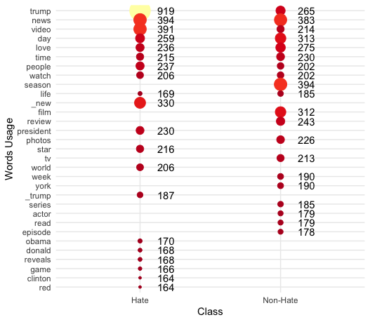

Word Usage for Hate and Non Hate Spreader

```r
train_words_target %>%
  group_by(AuthorSpreading) %>%
  top_n(20, n) %>%
  ungroup() %>%
  group_by(word) %>%
  mutate(tot_n = sum(n)) %>%
  ungroup() %>%
  arrange(desc(tot_n)) %>%
  mutate(word = factor(word, levels = rev(unique(word)))) %>%
  ggplot() +
  geom_point(aes(AuthorSpreading, word, size = n, color = n), show.legend = FALSE) +
  geom_text(aes(AuthorSpreading, word, label = n), hjust = -1) +
  scale_color_distiller(palette = "YlOrRd") +
  labs(y='Words Usage',x='Class')+
  scale_size_continuous(range = c(1, 10))
```

### **6.4) Tweet Length Comparison**

We next compare average length of tweets in number of characters for people spreading hate and those who are not. There was no significant difference found in length of tweets.

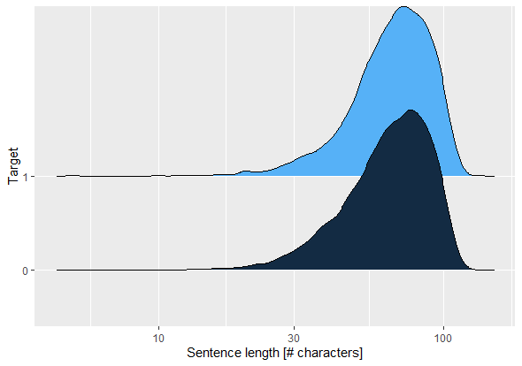

Average Tweet Length Comparison

```r
Sentence_length <- preprocessed_data_rows %>%
  mutate(sen_length = str_length(Tweet_Text)) %>%
  ggplot(aes(x=sen_length, y=as.factor(preprocessed_data_rows$Target), fill = preprocessed_data_rows$Target)) +
  geom_density_ridges() +
  scale_x_log10() +
  theme(legend.position = "none") +
  labs(x = "Sentence length [# characters]", y="Target")
```

#### **6.5) Topic Modeling**

We used LDA (Latent Dirichlet allocation) to discover prevalent topics used by Hate spreading and non Hate spreading Authors. LDA is unsupervised classification of documents , in our case , a document is a collection of tweets tweeted by Authors.  
We observed that Hate Spreading Author’s Tweeted majorly about “Politics” and then followed by Kardashians Jordyn Woods i.e. “Entertainment and Fashion industry”. Whereas, Non Hate Spreading Authors tweeted more about topics like “TV Series”, “Tech Products” and comparatively less about “Politics”.

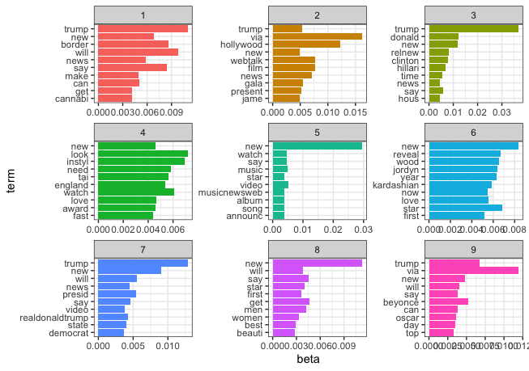

Topics Related to Hate Spreader

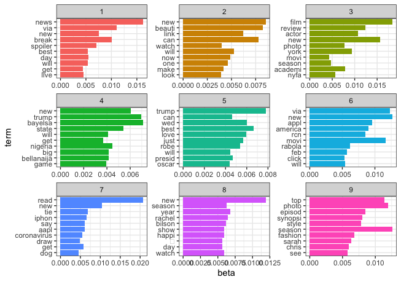

Topics Related to Non Hate Spreader

```r
top_terms %>%
  mutate(term = reorder(term, beta)) %>%
  ggplot(aes(term, beta, fill = factor(topic))) +
  geom_col(show.legend = FALSE) +
  facet_wrap(~ topic, scales = "free") +
  coord_flip() + theme_bw()
```

#### **6.6) Sentiment Analysis**

We examined the overall tweets in our training dataset for their sentiments , and the following Pie plot shows the distribution of different emotions exhibited in tweets of Hate spreading and non Hate spreading authors. We are not able to observe huge difference in emotions by both the category.

[figure not shown]

[figure not shown]

```r
ggplot(emotions_df_column_count_df,
       aes(x = "",
           y = percent,
           fill = Different_Emotions)) +
  geom_bar(width = 1,
           stat = "identity",
           color = "black") +
  geom_text(aes(label = paste0(Different_Emotions, "\n", round(percent,2))),
            position = position_stack(vjust = 0.5),
            color = "black") +
  coord_polar("y",
              start = 0,
              direction = -1) +
  theme_void() +
  theme(legend.position = "FALSE") +
  labs(title = "Tweets Emotion Analysis")
```